# Part II - Investigating Trip Features

## by Zion Oluwasegun

## Investigation Overview

Here, emphasis is laid on frequency, duration and length of trips. Important features are trip lenght, trip duration, dates, start and end times, start and end stations, gender, age group and user types.

## Dataset Overview

This data set includes information about individual rides made in a bike-sharing system covering the greater San Francisco Bay area. It contains 16 columns and 183412 rows which became 25 columns and 174952 rows after cleaning and feature engineering. This projects explores the periods and how often the bike rides/trips are made in the area.

## Peak times of trip starts and ends over 24 hours.

O=Most Users start their trips by 8AM in the morning, and end it by 5PM in the evening. This is one interesting insight to the data, as we know majority of the Users are most probably white or blue collar workers, or students who set out for work and close around those peak times.

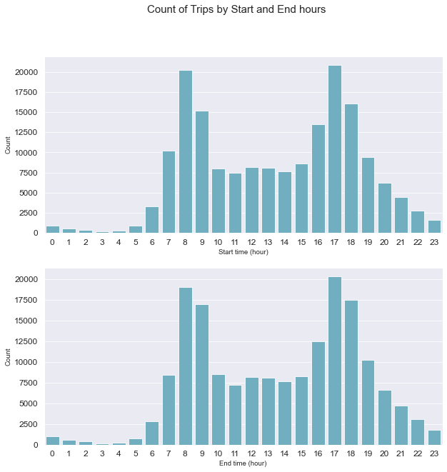

## Trend of trips across the month

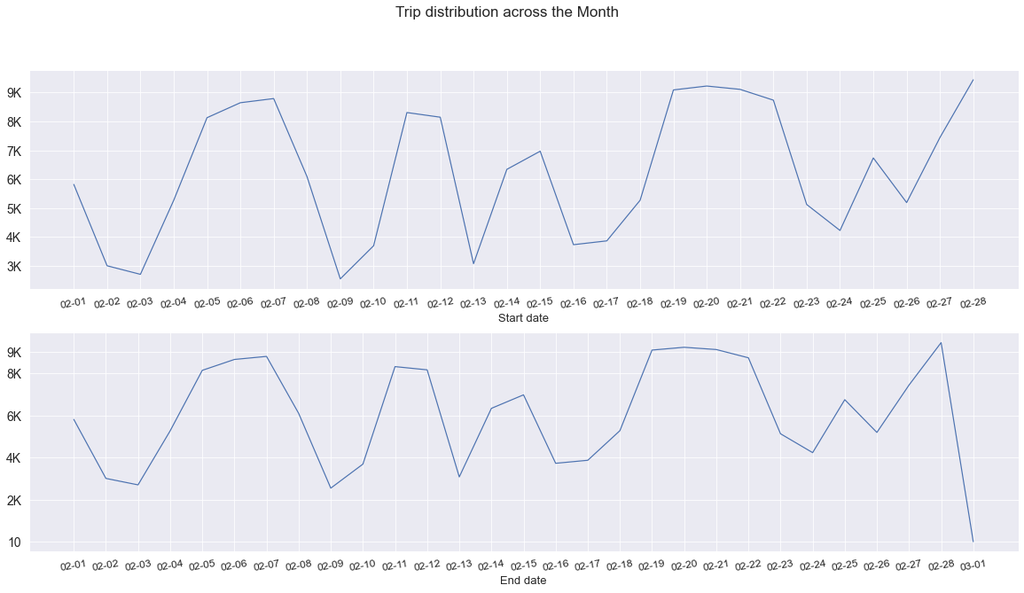

## How did those dates affect trips by User type?

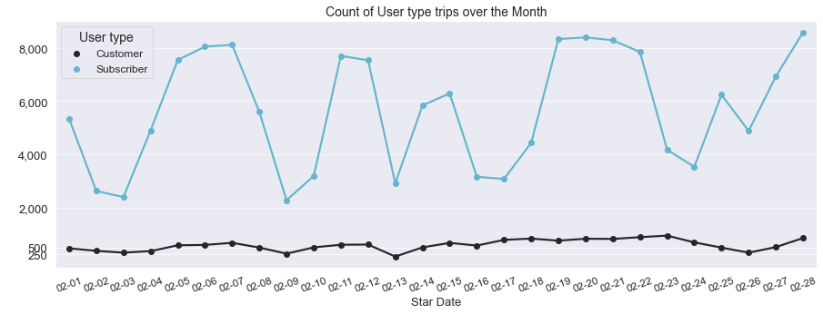

## Average distance ravelled by Users by demographics.

On average, Females travel longer distances compared to males, wih age group 30-40 averaging the most distance travelled by age group. Interestingly, Customers take longer distances, compared to Subscribers who are way more than Customers. Even though the difference is low, it shouldn't be overlooked.

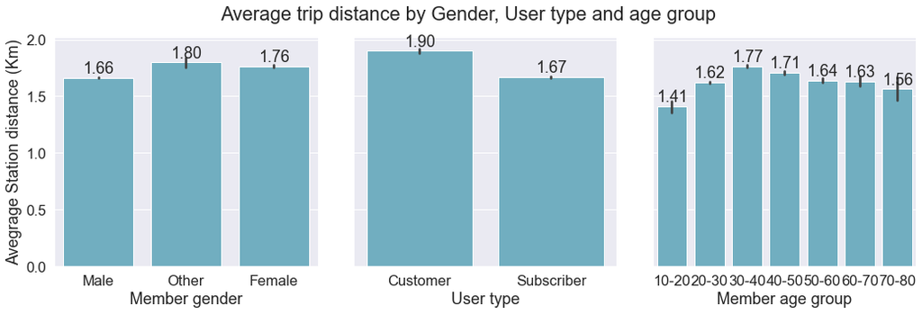

## Average time, in hours, trips by Users by demographics.

Oher Gender significantly spend more time on the road compared to Males and Females. Customers probably have the luxury of staying longer with the bikes, because averagely, they spend more time on trips han Subscribers. Across age groups, the average time spent on trips is roughly the same; 0.19 - 0.23 hours.

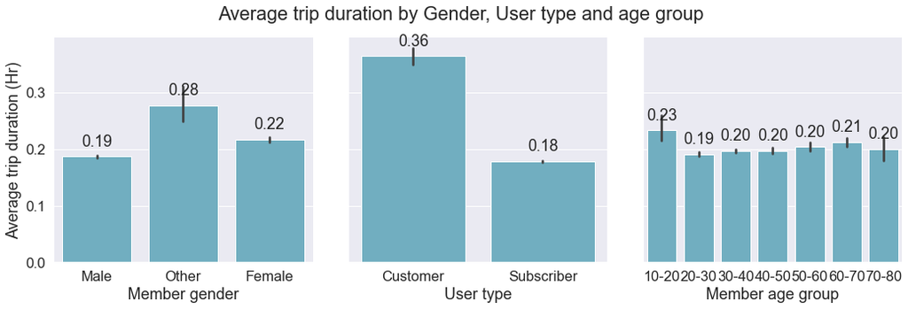

## What are the most used docking stations?

Majority of the most used docking staions are in/around Market Sreet). This area is the city's premier shopping and entertainment district containing the largest number of upscale department stores, chic boutiques, art galleries and theaters in the city. [(Source)](https://www.tripadvisor.com/Attraction_Review-g60713-d144424-Reviews-Market_Street-San_Francisco_California.html)

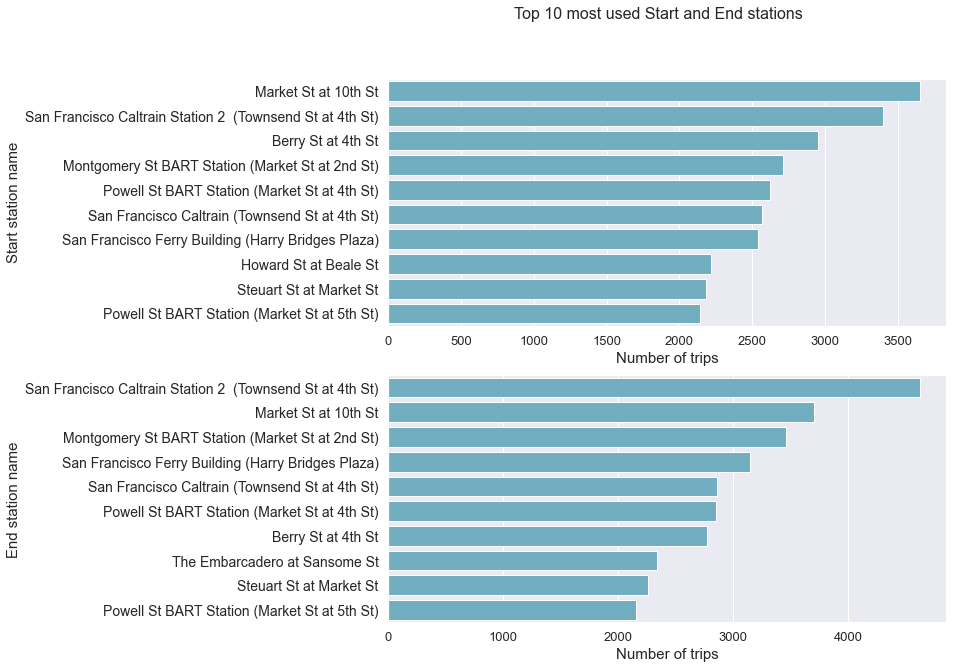